# Handson Praktikum 6 Anreg

# Library

```r
library(readxl) # untuk membaca data
library(GGally) # untuk menghasilkan matriks hubungan antarpeubah
library(corrplot) # untuk menghasilkan matriks korelasi
library(dplyr) # untuk manipulasi data
library(car) # untuk memeriksa multikolinearitas
library(stargazer) # untuk menampilkan hasil perbandingan regresi
library(lmtest) # untuk uji kehomogenan ragam sisaan dan saling bebas
library(olsrr) # untuk pemeriksaan amatan tidak biasa
```

Data

```r
dt <- read.csv2("C:\\Users\\a c e r\\OneDrive\\SEMESTER 4\\ANALISIS REGRESI\\DATA ANREG PRAK\\DATA USING FOR R.csv")
dt # menampilkan data
```

```
##     Ticker       NPM_Y      GPM_X1       OPM_X2      ROA_X5       ROE_X6
## 1     CPRO  0.04155000  0.20368000  0.090480000  0.07947000  0.104360000
## 2     MSJA  0.07433000  0.18787001  0.110950000  0.03813000  0.059550000
## 3     STAR  0.39859498  0.89708369 -0.090690000 -0.00276000  0.017460000
## 4     PTSN  0.05504000  0.14298001  0.075800000  0.04937000  0.096420005
## 5     CMNP  0.18215999  0.39001000  0.366450000  0.04372000  0.050540000
## 6     UNIC  0.07027000  0.13729000  0.134820000  0.05837000  0.090610000
## 7     INET  0.24544000  0.44139000  0.463113756  0.04389000  0.064320000
## 8     MDIY  0.14133000  0.56194000  0.206289990  0.15513000  0.311170000
## 9     CARS  0.04095000  0.12562999 -0.011030001  0.05481000  0.200350000
## 10    PGAS  0.08060000  0.17105000  0.145380000  0.04949000  0.120820000
## 11    PSSI  0.02623000  0.14142999  0.019580000  0.01097000  0.011089999
## 12    LPPF  0.13652000  0.66010004  0.018740000  0.16562750  0.377479999
## 13    PBRX  0.32406000  0.13861000  0.007770000  0.02679000  0.377479999
## 14    MKPI  0.39859498  0.54925996  0.463113756  0.08346000  0.148460000
```

[output cut: 327 more lines]

```r
str(dt) # menampilkan tipe data setiap peubah
```

```
## 'data.frame':    170 obs. of  8 variables:
##  $ Ticker      : chr  "CPRO" "MSJA" "STAR" "PTSN" ...
##  $ NPM_Y       : num  0.0416 0.0743 0.3986 0.055 0.1822 ...
##  $ GPM_X1      : num  0.204 0.188 0.897 0.143 0.39 ...
##  $ OPM_X2      : num  0.0905 0.1109 -0.0907 0.0758 0.3664 ...
##  $ ROA_X5      : num  0.07947 0.03813 -0.00276 0.04937 0.04372 ...
##  $ ROE_X6      : num  0.1044 0.0595 0.0175 0.0964 0.0505 ...
##  $ CurrRatio_X7: num  1.093 2.255 6.908 1.245 0.923 ...
##  $ DER_X13     : num  43.24 16.16 5.33 24.64 40.36 ...
```

```r
summary(dt) # menampilkan ringkasan data
```

```
##        Ticker        NPM_Y              GPM_X1             OPM_X2
##  Length   :170   Min.   :-0.18132   Min.   :-0.07754   Min.   :-0.18274
##  N.unique :170   1st Qu.: 0.03614   1st Qu.: 0.16619   1st Qu.: 0.05946
##  N.blank  :  0   Median : 0.09563   Median : 0.29164   Median : 0.12401
##  Min.nchar:  4   Mean   : 0.12276   Mean   : 0.33487   Mean   : 0.15431
##  Max.nchar:  4   3rd Qu.: 0.18112   3rd Qu.: 0.45855   3rd Qu.: 0.22092
##                  Max.   : 0.39859   Max.   : 0.89708   Max.   : 0.46311
##      ROA_X5             ROE_X6          CurrRatio_X7      DER_X13
##  Min.   :-0.06475   Min.   :-0.15904   Min.   :0.158   Min.   :  0.003
##  1st Qu.: 0.02164   1st Qu.: 0.04215   1st Qu.:1.243   1st Qu.:  4.588
##  Median : 0.04820   Median : 0.09018   Median :2.075   Median : 26.453
##  Mean   : 0.05438   Mean   : 0.11899   Mean   :2.748   Mean   : 40.638
##  3rd Qu.: 0.07923   3rd Qu.: 0.17628   3rd Qu.:3.509   3rd Qu.: 56.737
##  Max.   : 0.16563   Max.   : 0.37748   Max.   :6.908   Max.   :134.960
```

```r
dt <- select(dt, -Ticker)
```

# Eksplorasi Data

## Peubah Respon

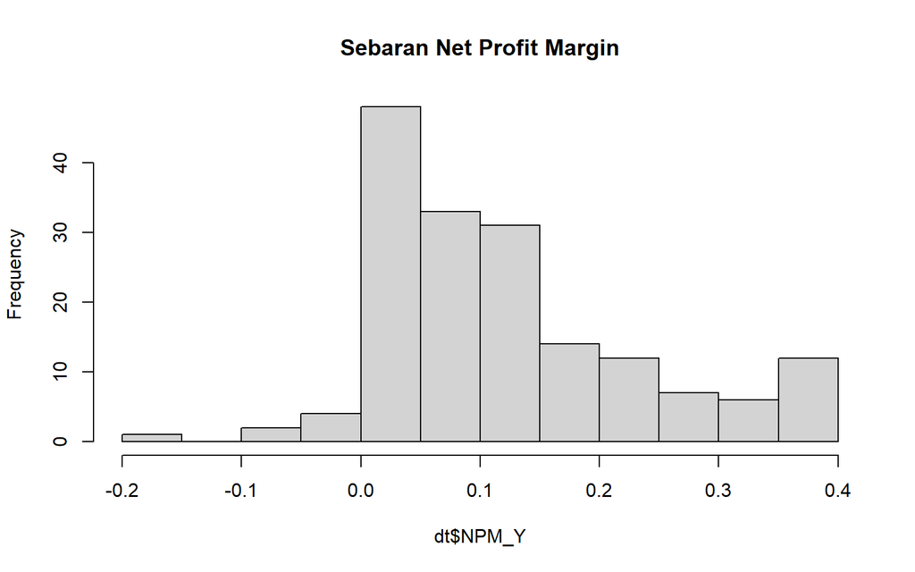

```r
hist(dt$NPM_Y, main = "Sebaran Net Profit Margin")
```

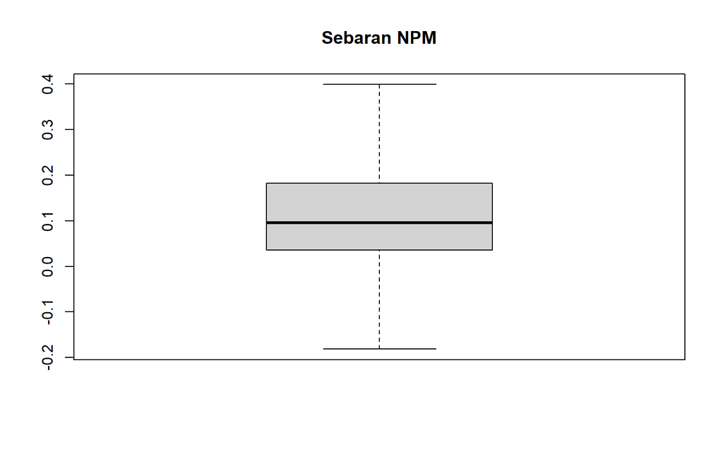

```r
boxplot(dt$NPM_Y, main = "Sebaran NPM")
```

## Peubah Pennjelas vs Peubah Respon

### GPM

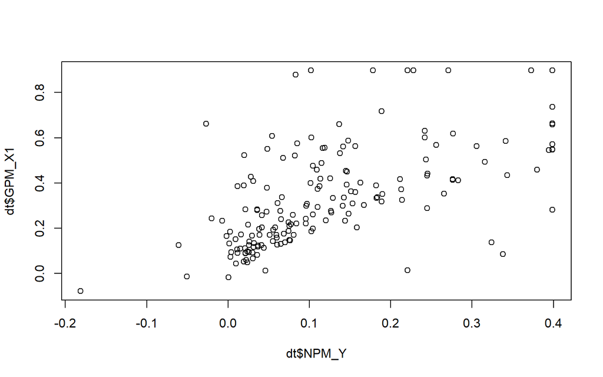

```r
plot(dt$NPM_Y, dt$GPM_X1)
```

Hubungan antara NPM dan GPM cenderung positif.

### OPM

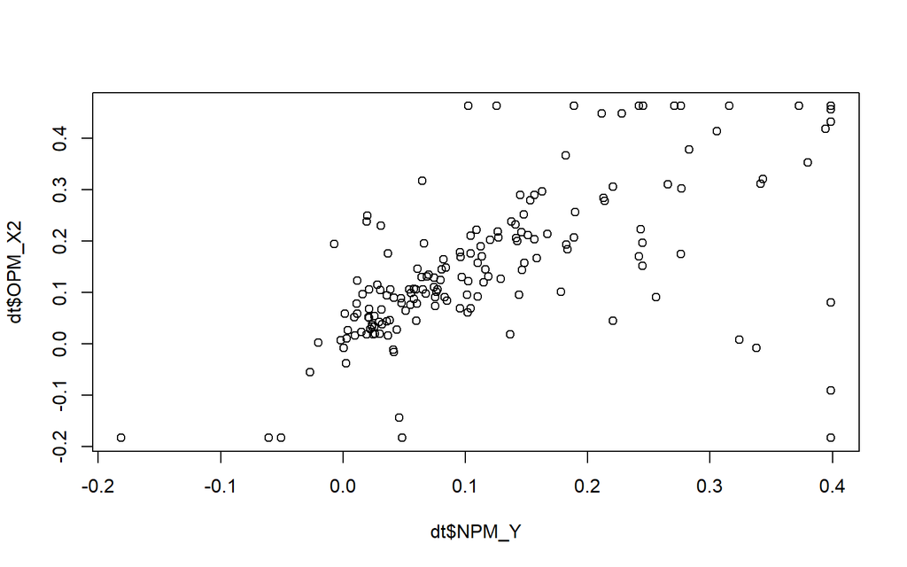

```r
plot(dt$NPM_Y, dt$OPM_X2)
```

Hubungan antara NPM dan OPM cenderung positif.

### ROA

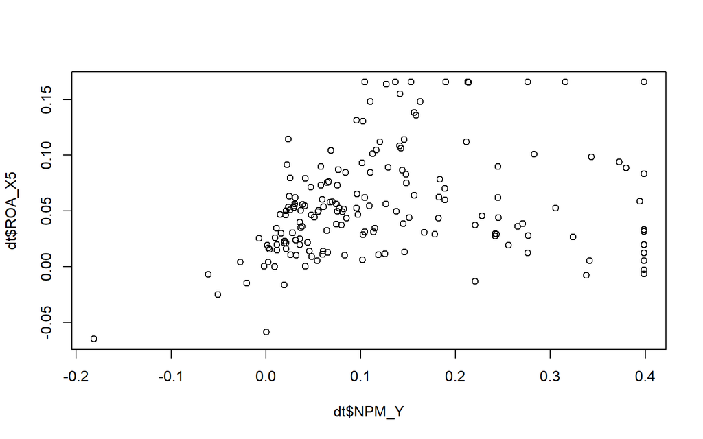

```r
plot(dt$NPM_Y, dt$ROA_X5)
```

Hubungan antara NPM dan ROA cenderung positif.

### ROE

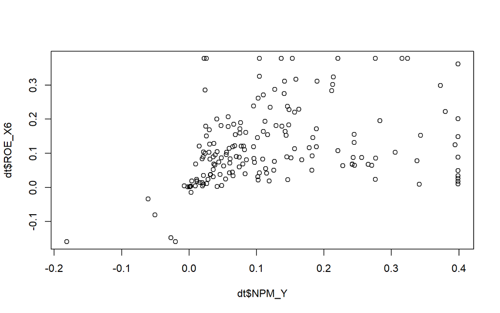

```r
plot(dt$NPM_Y, dt$ROE_X6)
```

Hubungan antara NPM dan ROE cenderung positif.

# CurrRatio

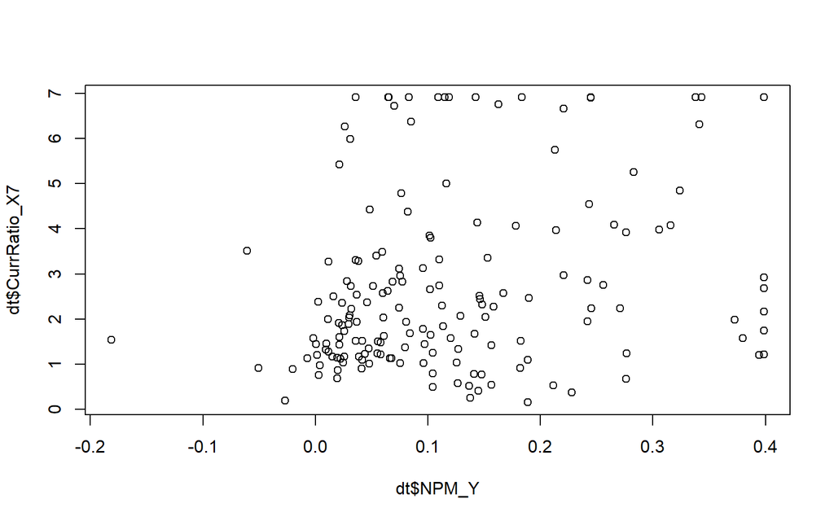

```r
plot(dt$NPM_Y, dt$CurrRatio_X7)
```

Hubungan antara NPM dan CurrRatio cenderung acak relatif tidak berhubungan.

## Korelasi

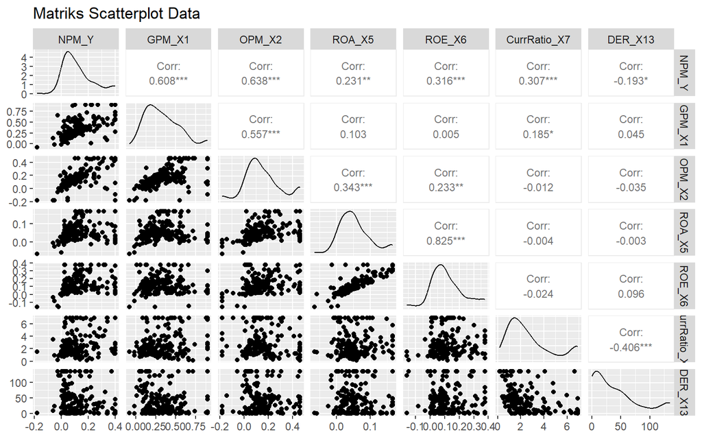

```r
ggpairs(dt,
        upper = list(continuous = wrap('cor', size = 3)),
        title = "Matriks Scatterplot Data")
```

Diagonal Utama: Menampilkan kurva estimasi kepadatan (density plot) dari masing-masing variabel untuk melihat bentuk distribusinya. Sebagian besar variabel tampak memiliki kemiringan (skewed), tidak murni normal.

Kiri-Bawah Diagonal: Menampilkan scatterplot (sebaran titik data) antar pasangan variabel untuk melihat pola linearitas atau keberadaan outlier.

Kanan-Atas Diagonal: Menampilkan nilai koefisien korelasi Pearson beserta tingkat signifikansinya yang ditandai dengan bintang (*** untuk $p < 0.001$, untuk $p < 0.01$, dan * untuk $p < 0.05$).

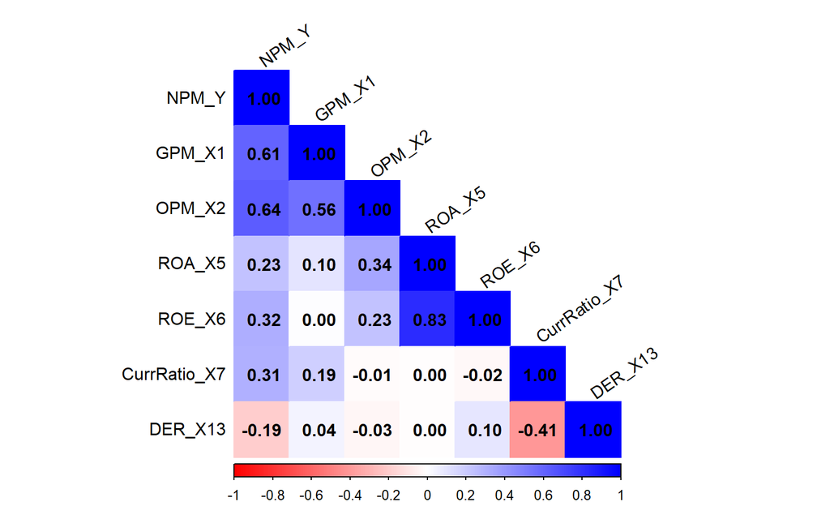

```r
cor_matrix <- cor(dt, use = "complete.obs")

corrplot(cor_matrix, method = "color", type = "lower",
         col = colorRampPalette(c("red", "white", "blue"))(200),
         addCoef.col = "black", tl.col = "black", tl.srt = 35)
```

Visualisasi kekuatan korelasi menggunakan gradasi warna. Warna biru tua menunjukkan korelasi positif yang kuat ($1$), warna merah menunjukkan korelasi negatif (hingga $-1$), dan warna putih/pudar menandakan korelasi mendekati nol (tidak ada hubungan).

# Interpretasi Hubungan

- OPM_X2 (Operating Profit Margin): Memiliki korelasi positif paling kuat dan sangat signifikan sebesar 0,64 (***). Pada scatterplot, terlihat jelas titik-titik data membentuk pola linear naik. Artinya, kenaikan margin laba operasional berbanding lurus secara signifikan dengan kenaikan margin laba bersih.
- GPM_X1 (Gross Profit Margin): Memiliki korelasi positif yang kuat dan sangat signifikan sebesar 0,61 (***). Ini menunjukkan bahwa efisiensi pada biaya produksi awal berkontribusi besar pada hasil akhir laba bersih.
- ROE_X6 (Return on Equity): Memiliki korelasi positif moderat yang signifikan sebesar 0,32 (***).
- CurrRatio_X7 (Current Ratio): Memiliki korelasi positif moderat yang signifikan sebesar 0,31 (***). Kemampuan likuiditas jangka pendek perusahaan berhubungan positif dengan profitabilitas margin bersihnya.
- ROA_X5 (Return on Asset): Memiliki korelasi positif lemah namun tetap signifikan sebesar 0,23 ().
- DER_X13 (Debt to Equity Ratio): Memiliki korelasi negatif yang lemah namun signifikan sebesar -0,19 (*). Warna merah muda pada korelogram mengonfirmasi hubungan terbalik ini. Artinya, semakin tinggi rasio utang terhadap ekuitas, ada kecenderungan margin laba bersih perusahaan sedikit menurun.

# Pemodelan

```r
model1 = lm(formula = NPM_Y ~ ., data = dt)
summary(model1)
```

```
##
## Call:
## lm(formula = NPM_Y ~ ., data = dt)
##
## Residuals:
##       Min        1Q    Median        3Q       Max
## -0.190481 -0.036879 -0.004817  0.028438  0.284081
##
## Coefficients:
##                Estimate Std. Error t value Pr(>|t|)
## (Intercept)  -0.0201755  0.0143001  -1.411 0.160191
## GPM_X1        0.2030813  0.0293015   6.931 9.26e-11 ***
## OPM_X2        0.3374468  0.0442438   7.627 1.89e-12 ***
## ROA_X5       -1.1805581  0.2005783  -5.886 2.19e-08 ***
## ROE_X6        0.6628448  0.0837587   7.914 3.62e-13 ***
## CurrRatio_X7  0.0104320  0.0029171   3.576 0.000459 ***
## DER_X13      -0.0005041  0.0001351  -3.730 0.000264 ***
## ---
## Signif. codes:  0 '***' 0.001 '**' 0.01 '*' 0.05 '.' 0.1 ' ' 1
##
## Residual standard error: 0.06547 on 163 degrees of freedom
## Multiple R-squared:  0.6916, Adjusted R-squared:  0.6802
## F-statistic: 60.92 on 6 and 163 DF,  p-value: < 2.2e-16
```

Persamaan yang terbentuk adalah
$$\hat{NPM}=-0.0201755+0.2030813GPM+0.337446OPM-1.1805581ROA+0.6628448ROE+0.0104320CurrRatio+-0.0005041DERR$$

- Variabel yang memberikan dampak positif terbesar terhadap peningkatan $NPM$ dalam model ini adalah $ROE$ ($+0.6628$) dan $OPM$ ($+0.3374$).
- Variabel $ROA$ menunjukkan anomali karena memiliki pengaruh negatif yang sangat kuat ($-1.1805$). Jika Anda sedang menyusun skripsi/penelitian, disarankan untuk mengecek uji Multikolinieritas (VIF), karena $ROA$, $ROE$, $GPM$, dan $OPM$ sering kali saling memengaruhi secara kuat.

# Pemeriksaan Multikolinearitas

## Perubahan Peubah

```r
mod1 <- lm(NPM_Y ~ ., dt[1:2])
mod2 <- lm(NPM_Y ~ ., dt[1:3])
mod3 <- lm(NPM_Y ~ ., dt[1:4])
mod4 <- lm(NPM_Y ~ ., dt[1:5])
mod5 <- lm(NPM_Y ~ ., dt)

stargazer(mod1, mod2, mod3, mod4, mod5,
          type = "text", single.row = TRUE)
```

```
##
## ===========================================================================================================================================
##                                                                       Dependent variable:
##                     -----------------------------------------------------------------------------------------------------------------------
##                                                                              NPM_Y
##                               (1)                     (2)                     (3)                     (4)                     (5)
## -------------------------------------------------------------------------------------------------------------------------------------------
## GPM_X1                 0.319*** (0.032)        0.192*** (0.035)        0.196*** (0.035)        0.218*** (0.031)        0.203*** (0.029)
## OPM_X2                                         0.336*** (0.051)        0.320*** (0.055)        0.326*** (0.049)        0.337*** (0.044)
## ROA_X5                                                                   0.126 (0.145)         -1.045*** (0.224)       -1.181*** (0.201)
## ROE_X6                                                                                         0.595*** (0.093)        0.663*** (0.084)
## CurrRatio_X7                                                                                                           0.010*** (0.003)
## DER_X13                                                                                                               -0.001*** (0.0001)
## Constant                 0.016 (0.013)           0.006 (0.012)           0.001 (0.013)          -0.014 (0.012)          -0.020 (0.014)
## -------------------------------------------------------------------------------------------------------------------------------------------
## Observations                  170                     170                     170                     170                     170
## R2                           0.370                   0.499                   0.501                   0.601                   0.692
## Adjusted R2                  0.366                   0.493                   0.492                   0.591                   0.680
## Residual Std. Error    0.092 (df = 168)        0.082 (df = 167)        0.082 (df = 166)        0.074 (df = 165)        0.065 (df = 163)
## F Statistic         98.480*** (df = 1; 168) 83.197*** (df = 2; 167) 55.634*** (df = 3; 166) 62.095*** (df = 4; 165) 60.915*** (df = 6; 163)
## ===========================================================================================================================================
## Note:                                                                                                           *p<0.1; **p<0.05; ***p<0.01
```

## Perubahan Banyak Data

```r
mod5_1 <- lm(NPM_Y ~ ., dt[1:15,])
stargazer(summary(mod5)$coefficients, summary(mod5_1)$coefficients,
          type = "text",
          font.size = "small")
```

```
##
## ====================================================
##              Estimate Std. Error t value Pr(> | t| )
## ----------------------------------------------------
## (Intercept)   -0.020    0.014    -1.411     0.160
## GPM_X1        0.203     0.029     6.931       0
## OPM_X2        0.337     0.044     7.627       0
## ROA_X5        -1.181    0.201    -5.886    0.00000
## ROE_X6        0.663     0.084     7.914       0
## CurrRatio_X7  0.010     0.003     3.576    0.0005
## DER_X13       -0.001    0.0001   -3.730    0.0003
## ----------------------------------------------------
##
## ====================================================
##              Estimate Std. Error t value Pr(> | t| )
## ----------------------------------------------------
## (Intercept)   -0.001    0.044    -0.034     0.974
## GPM_X1        0.438     0.056     7.860    0.00005
## OPM_X2        0.321     0.099     3.251     0.012
## ROA_X5        -2.464    0.441    -5.582     0.001
## ROE_X6        0.965     0.184     5.233     0.001
## CurrRatio_X7  0.002     0.008     0.194     0.851
## DER_X13       -0.001    0.001    -1.266     0.241
## ----------------------------------------------------
```

Terdapat dugaan parameter yang mengalami perubahan besar ketika jumlah amatan berbeda, mengindikasi model bermasalah.

## Akar Ciri

```r
x <- dt[-1]
r <- cor(x)
(ev <- eigen(r)$values)
```

```
## [1] 2.0855224 1.4982270 1.2677210 0.6616366 0.3275990 0.1592941
```

```r
# Simultan
if ((max(ev) / min(ev)) <= 100) {
  cat("Tidak ada multikolinearitas\n")
} else if ((max(ev) / min(ev)) > 100 & (max(ev) / min(ev)) <= 1000) {
  cat("Ada multikolinearitas yang lemah\n")
} else {
  cat("Ada multikolinearitas yang kuat\n")
}
```

```
## Tidak ada multikolinearitas
```

```r
# Parsial
if (all((max(ev) / ev) <= 1000)) {
  cat("Tidak ada multikolinearitas\n")
} else {
  cat("Ada multikolinearitas pada peubah penjelas ke:", which((max(ev) / ev) > 1000), "\n")
}
```

```
## Tidak ada multikolinearitas
```

## Nilai VIF

```r
vif(model1)
```

```
##       GPM_X1       OPM_X2       ROA_X5       ROE_X6 CurrRatio_X7      DER_X13
##     1.647669     1.718986     3.465756     3.331961     1.316183     1.296828
```

Hasil pemeriksaan dengan akar ciri menyatakan tidak ada multikolinearitas pada model karena tidak ada nilai $k>100$ secara simultan. Nilai VIF juga menunjukkan tidak ada peubah yang VIF nya lebih dari 10.

# Pengujian Asumsi

## Eksplorasi Grafik

### Plot Sisaan vs Y duga

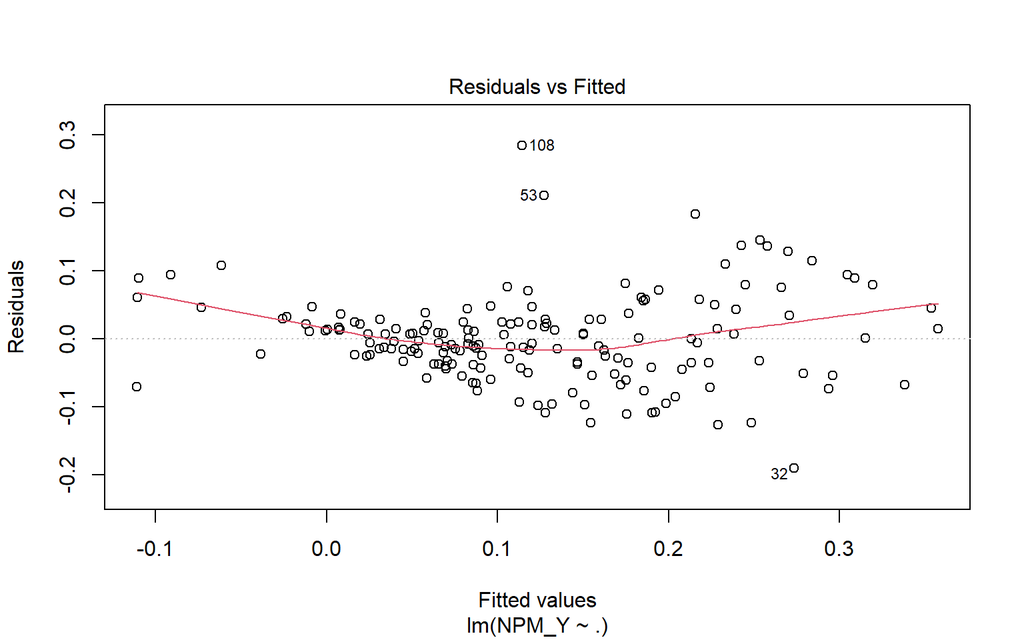

```r
plot(model1,1)
```

### Plot Sisaan vs Urutan

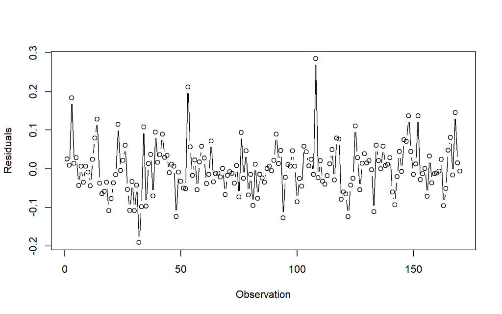

```r
plot(x = 1:dim(dt)[1],
     y = model1$residuals,
     type = 'b',
     ylab = "Residuals",
     xlab = "Observation")
```

Tebaran tidak berpola → sisaan saling bebas, model pas, tetapi ada indikasi terdapat autokorelasi karena hampir menyerupai pola autokorelasi negatif

### QQ plot

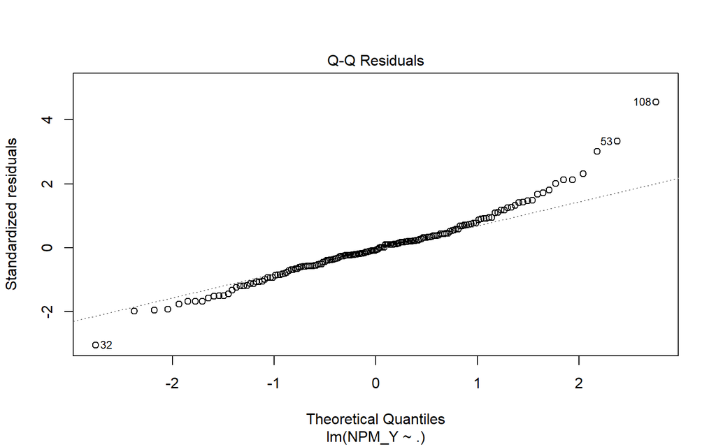

```r
plot(model1,2)
```

Amatan cenderung tidak mengikuti garis pola sehingga sisaan tidak menyebar normal

## Uji Formal

### Nilai harapan sisaan sama dengan nol

```r
t.test(model1$residuals,mu = 0,conf.level = 0.95)
```

```
##
##  One Sample t-test
##
## data:  model1$residuals
## t = -4.4206e-16, df = 169, p-value = 1
## alternative hypothesis: true mean is not equal to 0
## 95 percent confidence interval:
##  -0.009735105  0.009735105
## sample estimates:
##     mean of x
## -2.179966e-18
```

Nilai p pada uji t sama dengan 1 yang lebih besar dari alpha 5%, sehingga dinyatakan asumsi nilai harapan sisaan sama dengan nol terpenuhi

### Ragam sisaan homogen

```r
bptest(model1)
```

```
##
##  studentized Breusch-Pagan test
##
## data:  model1
## BP = 44.27, df = 6, p-value = 6.536e-08
```

### Sisaan saling bebas

```r
dwtest(model1)
```

```
##
##  Durbin-Watson test
##
## data:  model1
## DW = 1.7899, p-value = 0.08728
## alternative hypothesis: true autocorrelation is greater than 0
```

### Normalitas Sisaan

```r
shapiro.test(model1$residuals)
```

```
##
##  Shapiro-Wilk normality test
##
## data:  model1$residuals
## W = 0.9626, p-value = 0.0001585
```

# Pemeriksaan Amatan Tidak Biasa

```r
#fungsi
ri_stud <- rstudent(model1)
ri_stan <- rstandard(model1)
hii_fungsi <- hatvalues(model1)

#manual
X <- model.matrix(model1)
X_inv_xt <- X %*% solve(t(X) %*% X) %*% t(X)
hii_manual <- diag(X_inv_xt)
anova_model <- anova(model1)
s <- sqrt(anova_model["Residuals", "Mean Sq"])
ei <- model1$residuals
ri_manual <- ei/(s*sqrt(1-hii_manual))

nilai <- data.frame(ri_stud, ri_stan, ri_manual, hii_fungsi, hii_manual)
nilai
```

```
##          ri_stud      ri_stan    ri_manual  hii_fungsi  hii_manual
## 1    0.383145130  0.384151843  0.384151843 0.022179768 0.022179768
## 2    0.139107302  0.139527652  0.139527652 0.012851875 0.012851875
## 3    3.090216598  3.012229604  3.012229604 0.139146747 0.139146747
## 4    0.221135117  0.221783112  0.221783112 0.015697780 0.015697780
## 5    0.438100388  0.439190378  0.439190378 0.030995091 0.030995091
## 6   -0.678281891 -0.679408086 -0.679408086 0.046326272 0.046326272
## 7    0.107942109  0.108270857  0.108270857 0.046690070 0.046690070
## 8   -0.548015774 -0.549195755 -0.549195755 0.048256942 0.048256942
## 9    0.099948446  0.100253363  0.100253363 0.029499873 0.029499873
## 10  -0.127726576 -0.128113737 -0.128113737 0.011129236 0.011129236
## 11  -0.683050394 -0.684170838 -0.684170838 0.038995708 0.038995708
## 12   0.396675334  0.397704658  0.397704658 0.134569424 0.134569424
## 13   1.326176019  1.323100169  1.323100169 0.168515630 0.168515630
## 14   2.020417324  2.001582476  2.001582476 0.038725039 0.038725039
```

[output cut: 156 more lines]

## Pencilan

```r
for (i in 1:dim(nilai)[1]){
  absri <- abs(nilai[,2])
  pencilan <- which(absri > 2)
}
pencilan
```

```
## [1]   3  14  32  53 108 148 152 168
```

Amatan ke 3, 14, 32, 53, 108, 148, 152, dan 168 terdeteksi sebagai pencilan

## Leverage

```r
n <- dim(dt)[1]
p <- length(model1$coefficients)

for (i in 1:dim(nilai)[1]){
  cutoff <- 2*p/n
  titik_leverage <- which(hii_fungsi > cutoff)
}
titik_leverage
```

```
##   3  12  13  18  27  32  33  42  50  75  78  81 108 121 130 143
##   3  12  13  18  27  32  33  42  50  75  78  81 108 121 130 143
```

Amatan ke 3, 12, 13, 18, 27, 32, 33, 42, 50, 75, 78, 81, 108, 121, 130, dan 143 terdeteksi sebagai titik leverage

## Amatan Berpengaruh

### Jarak Cook

```r
di <- cooks.distance(model1)
f <- qf(0.05,p,n-p, lower.tail = F)
data.frame(di, di>f)
```

```
##               di di...f
## 1   4.781958e-04  FALSE
## 2   3.620818e-05  FALSE
## 3   2.095183e-01  FALSE
## 4   1.120647e-04  FALSE
## 5   8.814030e-04  FALSE
## 6   3.203251e-03  FALSE
## 7   8.201920e-05  FALSE
## 8   2.184723e-03  FALSE
## 9   4.364399e-05  FALSE
## 10  2.638877e-05  FALSE
## 11  2.713455e-03  FALSE
## 12  3.513480e-03  FALSE
## 13  5.068431e-02  FALSE
## 14  2.305649e-02  FALSE
```

[output cut: 156 more lines]

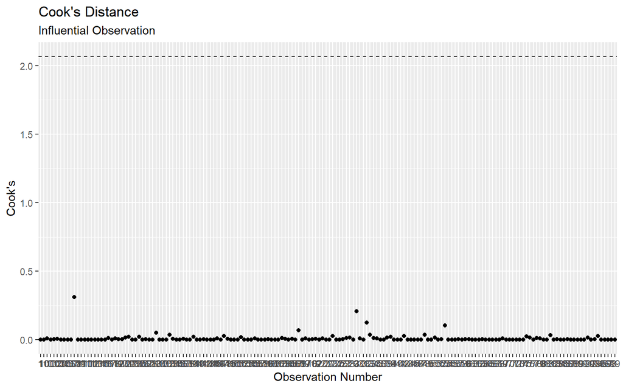

```r
cooks_crit = f
model_cooks <- cooks.distance(model1)
df <- data.frame(obs = names(model_cooks),
                 cooks = model_cooks)
ggplot(df, aes(y = cooks, x = obs)) +
  geom_point() +
  geom_hline(yintercept = cooks_crit, linetype="dashed") +
  labs(title = "Cook's Distance",
       subtitle = "Influential Observation ",
       x = "Observation Number",
       y = "Cook's")
```

```r
DFFITSi <- dffits(model1)

amatan_berpengaruh <- vector("list", dim(nilai)[1])
for (i in 1:dim(nilai)[1]) {
  cutoff <- 2 * sqrt((p / n))
  amatan_berpengaruh[[i]] <- which(abs(DFFITSi) > cutoff)
}
berpengaruh <- unlist(amatan_berpengaruh)
amatan_berpengaruh <- sort(unique(berpengaruh))
amatan_berpengaruh
```

```
##  [1]   3  13  23  32  33  42  48  53  75  81  94 108 133 148 168
```

Amatan ke 3 13 23 32 33 42 48 53 75 81 94 108 133 148, dan 168 termasuk amatan berpengaruh sehingga sangat riskan jika disisihkan. Perlu ditelusuri lebih lanjut